# Forecasting of the USA Inflation using Different models under Timeseries

Anshuman Patnaik

2024-10-29

Introduction:

Understanding and accurately forecasting inflation is crucial for policymakers, economists, and investors. Inflation forecasting enables better decision-making in monetary policies, financial planning, and business strategy. With this study, we aim to investigate USA inflation through time series forecasting models. Specifically, the study explores several models, such as mean forecast, naïve forecast, seasonal naïve, and random walk forecasts. Each model’s accuracy is evaluated, and ARIMA modeling is utilized for more detailed analysis.

Literature Review:

Inflation forecasting has been widely studied, with numerous approaches introduced over the years. Traditional models, such as ARIMA (AutoRegressive Integrated Moving Average), have been widely applied due to their capacity to handle non-stationary data and produce reliable short-term forecasts. Advanced models, including seasonal and trend decomposition, are beneficial in capturing seasonal variations often observed in economic time series. Previous research has shown mixed results on which model performs best, with some findings indicating that simple models, such as random walk and naïve forecasts, perform similarly or better than complex ones when dealing with inflation data.

Data:

Methodology:

Data Transformation and Visualization: The data was loaded and initially visualized to observe patterns. Inflation was converted into a time series object to facilitate time series analysis.

Stationarity Testing: Stationarity, a critical property for time series forecasting, was checked using the Augmented Dickey-Fuller (ADF) test. Since non-stationary data can lead to unreliable models, we differenced the series until it achieved stationarity.

Modeling Techniques:

Mean Forecast: This approach assumes that future values will match the mean of past observations. Naïve Forecast: In this model, the last observed value is projected forward. Seasonal Naïve Forecast: Suitable for data with seasonality, this approach repeats previous seasonal patterns. Random Walk Forecast (RWF): This model assumes that changes in data follow a random path, making it appropriate for non-stationary data with trends. Evaluation Metrics: Each model was assessed based on key accuracy metrics, including RMSE (Root Mean Square Error) and MAPE (Mean Absolute Percentage Error). The Ljung-Box test checked for autocorrelation in residuals, ensuring model robustness.

ARIMA Modeling: After testing the initial models, ARIMA (AutoRegressive Integrated Moving Average) modeling was applied. The model was selected using auto.arima() in R, and its effectiveness was tested through residual analysis and forecast comparison.

Results and Discussion:

The findings indicate that the initial models (mean, naïve, seasonal naïve, and random walk) show varying degrees of accuracy:

```r
options(repos = c(CRAN = "https://cran.rstudio.com/"))
```

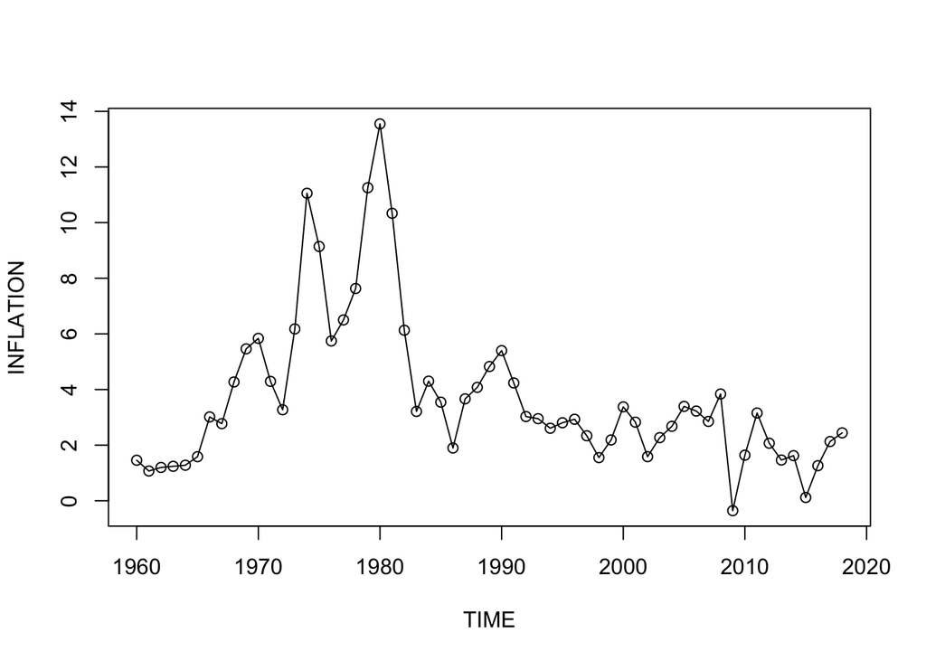

```r
#INSTALLING PACKAGES
library(ggplot2)
library(tidyverse)
install.packages("forecast")
library(forecast)
install.packages("tseries")
library(tseries)
library(vars)
install.packages("fpp2")
library(fpp2)
install.packages("readxl")
library(readxl)
USA_GDP_WORKING_ <- read_excel("/Users/anshuman/Desktop/TERM PAPER, BAIJU/DATASET/USA/USAGDPWORKING1.xls")


#VIEWING THE DATASET USA_GDP_WORKING (includes inflation)

NewDATA=USA_GDP_WORKING_[1:59,c(1,3)]


#PLOTTING THE VARIABLES OF THE DATASET
plot(NewDATA$TIME,y=NewDATA$INFLATION,type = ("o"),xlab=("TIME"),ylab=("INFLATION"))
```

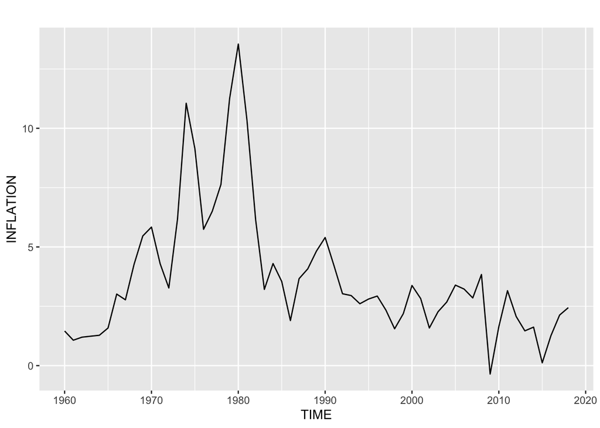

```r
#converting inflation into timeseries dataset

USAINFLATIONTIME=ts(NewDATA$INFLATION,start = min(NewDATA$TIME),end = max(NewDATA$TIME),frequency = 1)

#time plots of the datasets
autoplot(USAINFLATIONTIME)+xlab("TIME")+ylab("INFLATION")
```

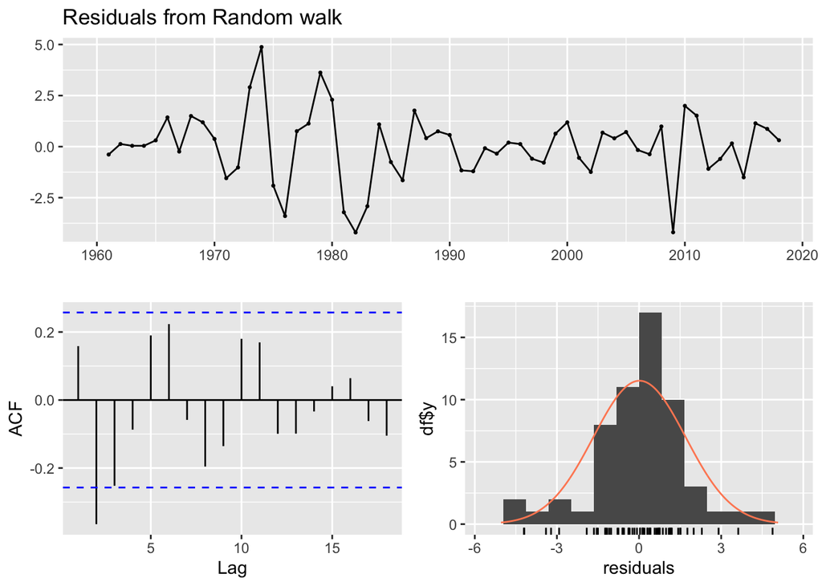

```
##
##  Ljung-Box test
##
## data:  Residuals from Random walk
## Q* = 26.575, df = 10, p-value = 0.003039
##
## Model df: 0.   Total lags used: 10
```

```r
#CHECKING RESIDUALS FOR OUR INFLATION
checkresiduals(rwf(USAINFLATIONTIME))
```

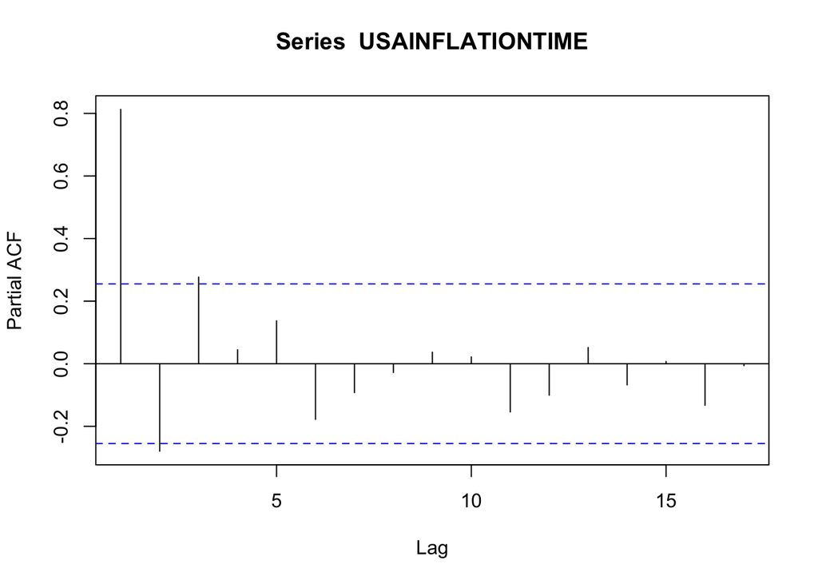

```r
#autocorrelation check for the data

pacf(USAINFLATIONTIME)
```

```r
#checking stationary
adf.test(USAINFLATIONTIME)
```

```
##
##  Augmented Dickey-Fuller Test
##
## data:  USAINFLATIONTIME
## Dickey-Fuller = -2.5748, Lag order = 3, p-value = 0.3425
## alternative hypothesis: stationary
```

```r
USAINFLATIONdiff=diff(USAINFLATIONTIME)
adf.test(USAINFLATIONdiff)
```

```
##
##  Augmented Dickey-Fuller Test
##
## data:  USAINFLATIONdiff
## Dickey-Fuller = -5.5041, Lag order = 3, p-value = 0.01
## alternative hypothesis: stationary
```

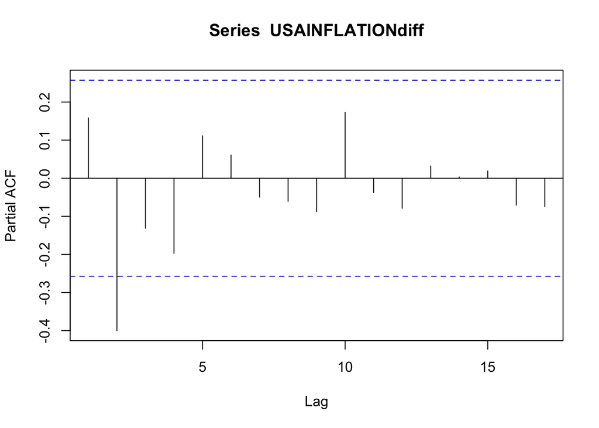

```r
#checking if white noise is occurring
pacf(USAINFLATIONdiff)
```

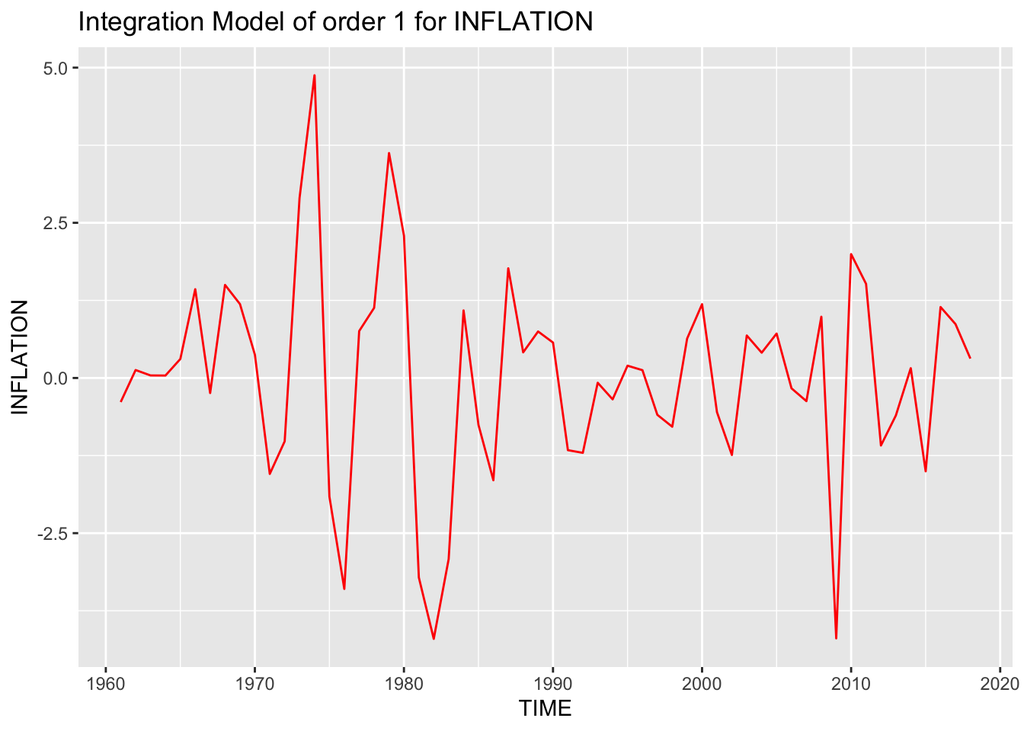

```r
#AUTOPLOT FOR THE DIFFERENCED VARIABALES
autoplot(USAINFLATIONdiff,xlab=("TIME"),ylab = ("INFLATION"),col=c("red"))+ggtitle("Integration Model of order 1 for INFLATION")
```

```r
#CREATING A TRAINING DATA FOR CHECKING THE ACCURACY OF OUR FORECASTING MODELS
#for inflation data
USAINFLATIONTIME_2=window(USAINFLATIONdiff,start=1961,end=1995)
INFLA1=meanf(USAINFLATIONTIME_2,h=10)
INFLA2=naive(USAINFLATIONTIME_2,h=10)
INFLA3=snaive(USAINFLATIONTIME_2,h=10)
INFLA4=rwf(USAINFLATIONTIME_2,h=10,drift = FALSE)



#creating a test data and checking accuracy
USAINFLATIONTIME_3=window(USAINFLATIONdiff,start=1996)

accuracy(INFLA1,USAINFLATIONTIME_3)
```

```
##                         ME      RMSE       MAE      MPE     MAPE      MASE
## Training set -6.344132e-18 1.8925713 1.4064432 94.29607 94.29607 0.8690652
## Test set      2.023432e-02 0.7588745 0.6849832 96.11188 96.11188 0.4232628
##                    ACF1 Theil's U
## Training set 0.29458906        NA
## Test set     0.07110285 0.9567035
```

```r
accuracy(INFLA2,USAINFLATIONTIME_3)
```

```
##                       ME      RMSE      MAE      MPE      MAPE      MASE
## Training set  0.01721265 2.2794443 1.618340 55.66419 198.91278 1.0000000
## Test set     -0.13924538 0.7712784 0.667526 80.00531  91.48424 0.4124757
##                     ACF1 Theil's U
## Training set -0.01218417        NA
## Test set      0.07110285  1.113384
```

```r
accuracy(INFLA3,USAINFLATIONTIME_3)
```

```
##                       ME      RMSE      MAE      MPE      MAPE      MASE
## Training set  0.01721265 2.2794443 1.618340 55.66419 198.91278 1.0000000
## Test set     -0.13924538 0.7712784 0.667526 80.00531  91.48424 0.4124757
##                     ACF1 Theil's U
## Training set -0.01218417        NA
## Test set      0.07110285  1.113384
```

```r
accuracy(INFLA4,USAINFLATIONTIME_3)
```

```
##                       ME      RMSE      MAE      MPE      MAPE      MASE
## Training set  0.01721265 2.2794443 1.618340 55.66419 198.91278 1.0000000
## Test set     -0.13924538 0.7712784 0.667526 80.00531  91.48424 0.4124757
##                     ACF1 Theil's U
## Training set -0.01218417        NA
## Test set      0.07110285  1.113384
```

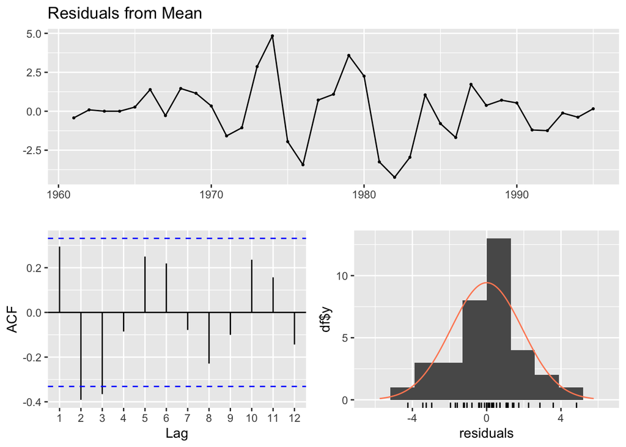

```
##
##  Ljung-Box test
##
## data:  Residuals from Mean
## Q* = 20.149, df = 7, p-value = 0.005257
##
## Model df: 0.   Total lags used: 7
```

```r
#checking for autocorrealtions
checkresiduals(INFLA1)#significant p value
```

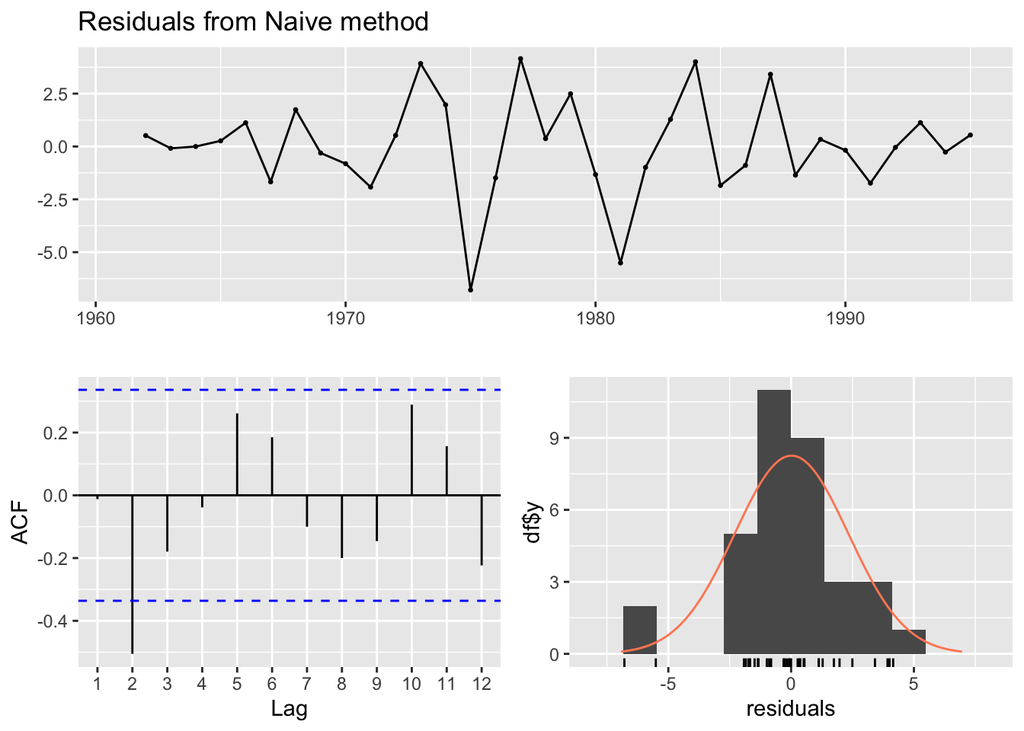

```
##
##  Ljung-Box test
##
## data:  Residuals from Naive method
## Q* = 15.93, df = 7, p-value = 0.02576
##
## Model df: 0.   Total lags used: 7
```

```r
checkresiduals(INFLA2)#significant p value
```

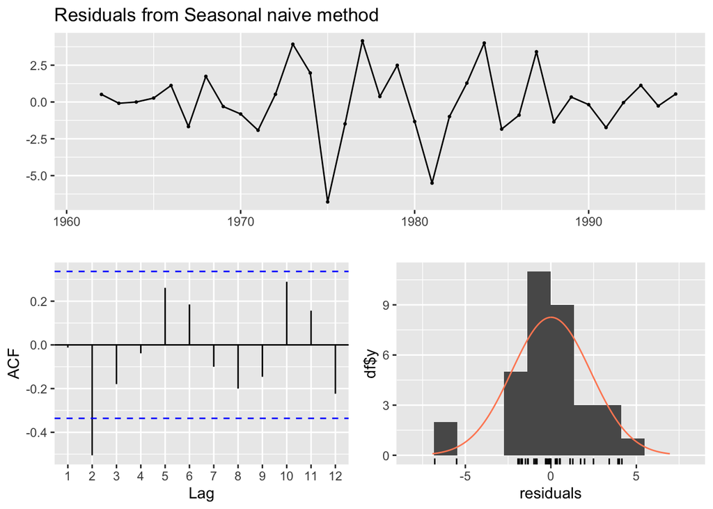

```
##
##  Ljung-Box test
##
## data:  Residuals from Seasonal naive method
## Q* = 15.93, df = 7, p-value = 0.02576
##
## Model df: 0.   Total lags used: 7
```

```r
checkresiduals(INFLA3)#significant p value
```

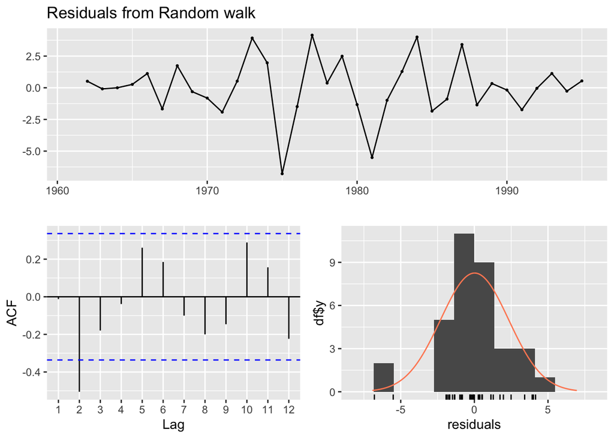

```
##
##  Ljung-Box test
##
## data:  Residuals from Random walk
## Q* = 15.93, df = 7, p-value = 0.02576
##
## Model df: 0.   Total lags used: 7
```

```r
checkresiduals(INFLA4)#significant p value
```

DUE TO SIGNIFICANT P VALUE< WE REJECT THE NULL OF NO AUTO CORRELATION IN THE FORECAST MODELS. WE THUS CREATE A NEW DATA SET WITH SECOND DIFFERENCE OF THE INFLATION DATA TO FORECAST OUR MODELS

```r
#checking for Second Difference
#CREATING A TRAINING DATA FOR CHECKING THE ACCURACY OF OUR FORECASTING MODELS
#for inflation data
USAINFLATIONTIME_2=window(diff(USAINFLATIONdiff),start=1961,end=1995)
INFLA1a=meanf(USAINFLATIONTIME_2,h=10)
INFLA2b=naive(USAINFLATIONTIME_2,h=10)
INFLA3c=snaive(USAINFLATIONTIME_2,h=10)
INFLA4d=rwf(USAINFLATIONTIME_2,h=10,drift = FALSE)


#creating a test data and checking accuracy
USAINFLATIONTIME_3=window(diff(USAINFLATIONdiff),start=1996)

accuracy(INFLA1a,USAINFLATIONTIME_3)
```

```
##                        ME     RMSE       MAE      MPE     MAPE      MASE
## Training set 7.510332e-17 2.279379 1.6193528 132.3893 132.3893 0.6120015
## Test set     3.454056e-02 1.012214 0.7930518 103.4107 103.4107 0.2997178
##                     ACF1 Theil's U
## Training set -0.01218417        NA
## Test set     -0.09983095 0.9658152
```

```r
accuracy(INFLA2b,USAINFLATIONTIME_3)
```

```
##                         ME     RMSE       MAE       MPE     MAPE      MASE
## Training set  0.0008149222 3.289468 2.6459948 -155.8666 518.2452 1.0000000
## Test set     -0.4904402650 1.124240 0.9448129  207.4366 222.6019 0.3570729
##                     ACF1 Theil's U
## Training set -0.25478528        NA
## Test set     -0.09983095  1.358236
```

```r
accuracy(INFLA3c,USAINFLATIONTIME_3)
```

```
##                         ME     RMSE       MAE       MPE     MAPE      MASE
## Training set  0.0008149222 3.289468 2.6459948 -155.8666 518.2452 1.0000000
## Test set     -0.4904402650 1.124240 0.9448129  207.4366 222.6019 0.3570729
##                     ACF1 Theil's U
## Training set -0.25478528        NA
## Test set     -0.09983095  1.358236
```

```r
accuracy(INFLA4d,USAINFLATIONTIME_3)
```

```
##                         ME     RMSE       MAE       MPE     MAPE      MASE
## Training set  0.0008149222 3.289468 2.6459948 -155.8666 518.2452 1.0000000
## Test set     -0.4904402650 1.124240 0.9448129  207.4366 222.6019 0.3570729
##                     ACF1 Theil's U
## Training set -0.25478528        NA
## Test set     -0.09983095  1.358236
```

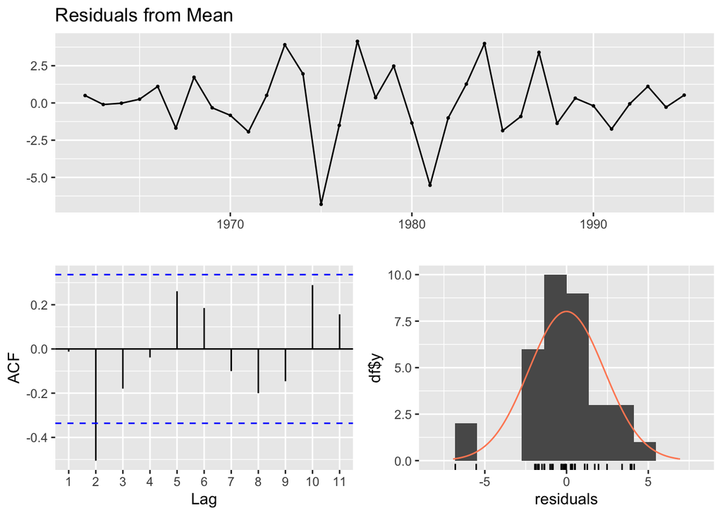

```
##
##  Ljung-Box test
##
## data:  Residuals from Mean
## Q* = 15.93, df = 7, p-value = 0.02576
##
## Model df: 0.   Total lags used: 7
```

```r
#checking for autocorrelations
checkresiduals(INFLA1a)#significant p value
```

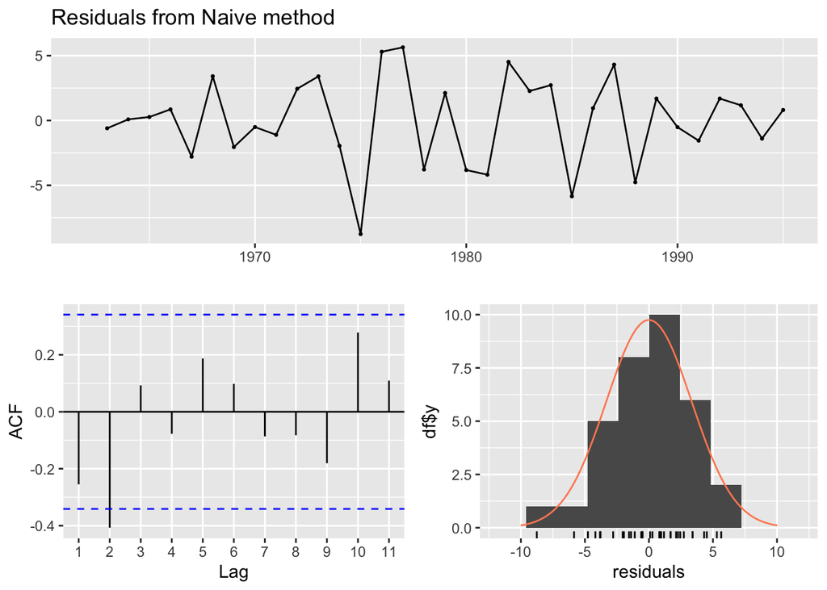

```
##
##  Ljung-Box test
##
## data:  Residuals from Naive method
## Q* = 11.281, df = 7, p-value = 0.1268
##
## Model df: 0.   Total lags used: 7
```

```r
checkresiduals(INFLA2b)#insignificant p value
```

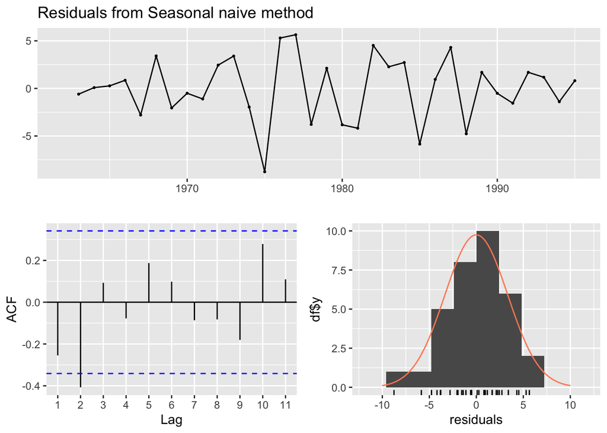

```
##
##  Ljung-Box test
##
## data:  Residuals from Seasonal naive method
## Q* = 11.281, df = 7, p-value = 0.1268
##
## Model df: 0.   Total lags used: 7
```

```r
checkresiduals(INFLA3c)#insignificant p value
```

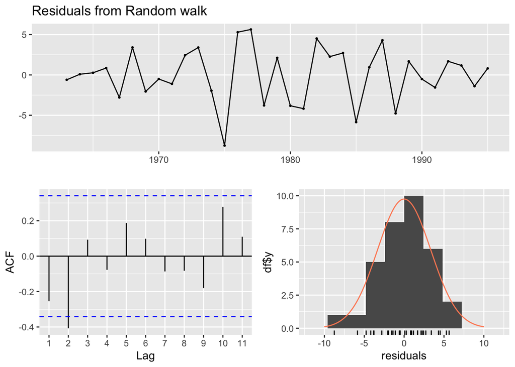

```
##
##  Ljung-Box test
##
## data:  Residuals from Random walk
## Q* = 11.281, df = 7, p-value = 0.1268
##
## Model df: 0.   Total lags used: 7
```

```r
checkresiduals(INFLA4d)#insignificant p value
```